# JapanTrendAnalysis For Leisure Offers / Activities

Vivek

January 4, 2016

```r
load('data.leisure.Rda')
data.beauty <- data.leisure
```

Taking only recent data (2015) data

```r
data.beauty2015 <- data.beauty[ data.beauty$start_date >= as.Date('2015-01-01') &
                                  data.beauty$start_date <= as.Date('2015-09-30'),]
```

Get top deals taking sum of gb on life of deal only, not in deal bank

```r
deal.gb <- data.beauty2015[ order_seq < deal_duration,list( gb = sum(gb)),by="deal_id"]
top_deals <- deal.gb[ deal.gb$gb >= quantile(deal.gb$gb,.7),]
```

Get top deals which have deal duration of 10 days, And Summerize it at order_seq level

```r
data.beauty.top.dd10 <- data.beauty2015[ deal_duration == 10 & deal_id %in%                                                   top_deals$deal_id,
                                         list( gb = sum(gb)),by="order_seq"]
data.beauty.top.dd10 <- data.beauty.top.dd10[ order_seq >=0,]
temp.df <- data.table( order_seq = seq(min(data.beauty.top.dd10$order_seq),
                                       max(data.beauty.top.dd10$order_seq),1))
data.beauty.top.dd10 <- merge(temp.df,data.beauty.top.dd10,by="order_seq",all.x = T)
data.beauty.top.dd10$gb[ is.na(data.beauty.top.dd10$gb)] <- 0
```

Get predicted demand

```r
exponential.model <- lm(log(gb)~order_seq,data = data.beauty.top.dd10[ order_seq >= 25 & order_seq <= 40,])
data.beauty.top.dd10$pre_after25 <- exp(predict(exponential.model,data.beauty.top.dd10))
exponential.model <- lm(log(gb+1)~order_seq,data = data.beauty.top.dd10[ order_seq <= 9,])
data.beauty.top.dd10$pre_before10 <- exp(predict(exponential.model,data.beauty.top.dd10))

write.csv(data.beauty.top.dd10,file = 'leiure_predicted_trend.csv',row.names = F)
```

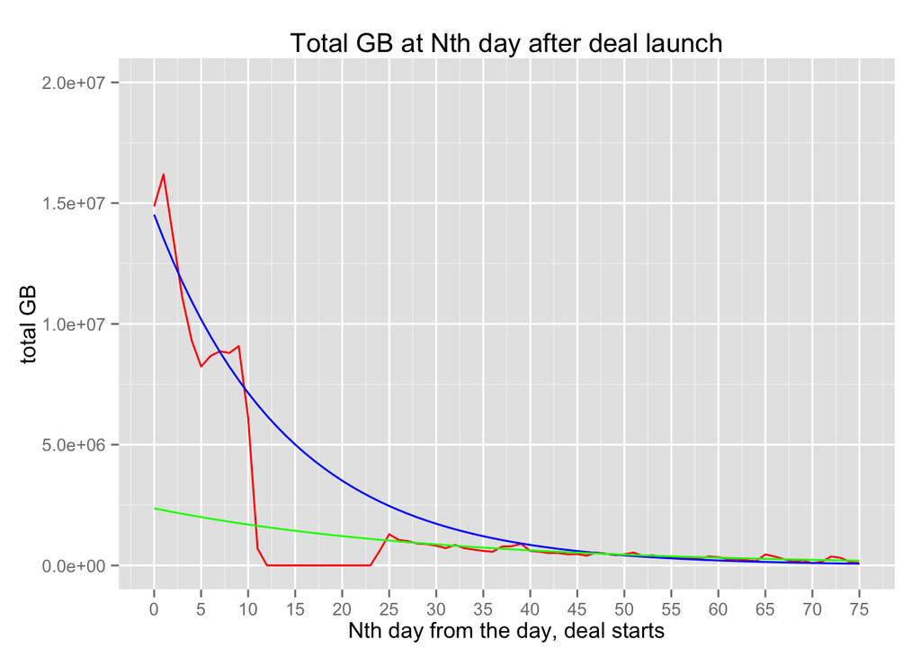

```r
ggplot(aes(x=order_seq),data=data.beauty.top.dd10) +
  geom_line(aes(y=gb,group=1),stat='identity',color='red')+
  geom_line(aes(y=pre_before10,group=1),stat='identity',color='blue')+
  geom_line(aes(y=pre_after25,group=1),stat='identity',color='green')+
  scale_x_continuous(limits=c(0,75),breaks=seq(0,150,5))+
  scale_y_continuous(limits=c(0,20000000))+
  labs(y = 'total GB',x = 'Nth day from the day, deal starts',title="Total GB at Nth day after deal launch")
```

number of deals launched in Jan-2015 to Sep-2015

```r
length(unique(data.beauty2015$deal_id))
```

```
## [1] 1685
```

Total GB for deals launched in Jan-2015 to Sep-2015

```r
sum(as.numeric(data.beauty2015$gb))
```

```
## [1] 404284855
```

number of top 30% deals launched in Jan-2015 to Sep-2015

```r
length(unique(data.beauty2015[deal_id %in% top_deals$deal_id]$deal_id))
```

```
## [1] 499
```

Total GB for top 30% deals launched in Jan-2015 to Sep-2015

```r
sum(data.beauty2015[deal_id %in% top_deals$deal_id]$gb)
```

```
## [1] 296220708
```

number of top deals which have deal duration 10 and launched in Jan-2015 to Sep-2015

```r
length(unique(data.beauty2015[ deal_duration == 10 & deal_id %in% top_deals$deal_id]$deal_id))
```

```
## [1] 266
```

Total GB for top deals have deal duration 10 and launched in Jan-2015 to Sep-2015

```r
sum(data.beauty2015[ deal_duration == 10 & deal_id %in% top_deals$deal_id]$gb)
```

```
## [1] 143878129
```

Deal Duration Distribution

```r
temp.d <- unique(data.beauty2015[ deal_id %in% top_deals$deal_id,list(deal_id,deal_duration)])
quantile(temp.d$deal_duration  ,seq(0,1,.05))
```

```
##   0%   5%  10%  15%  20%  25%  30%  35%  40%  45%  50%  55%  60%  65%  70%
##    7   10   10   10   10   10   10   10   10   10   10   10   14   15   20
##  75%  80%  85%  90%  95% 100%
##   20   20   20   20   25   35
```

Top Deals taken contributing to how much GB??

```r
sum(data.beauty2015[ deal_duration == 10 & deal_id %in% top_deals$deal_id]$gb)/ sum(as.numeric(data.beauty2015$gb))*100
```

```
## [1] 35.58831
```

Gain for blue line for 17 days and 25 days, Here blue line is prediction for starting 10 days

for 17 days,

```r
sum(data.beauty.top.dd10[ order_seq <= 16, pre_before10])
```

```
## [1] 148527148
```

```r
sum(data.beauty.top.dd10[ order_seq <= 16, gb])
```

```
## [1] 115534866
```

```r
sum(data.beauty.top.dd10[ order_seq >= 10 & order_seq <= 16, pre_before10])
```

```
## [1] 40796838
```

```r
sum(data.beauty.top.dd10[ order_seq >= 10 & order_seq <= 16, gb])
```

```
## [1] 6805137
```

for 25 days,

```r
sum(data.beauty.top.dd10[ order_seq <= 24, pre_before10])
```

```
## [1] 175983523
```

```r
sum(data.beauty.top.dd10[ order_seq <= 24, gb])
```

```
## [1] 116150332
```

```r
sum(data.beauty.top.dd10[ order_seq >= 10 & order_seq <= 24, pre_before10])
```

```
## [1] 68253212
```

```r
sum(data.beauty.top.dd10[ order_seq >= 10 & order_seq <= 24, gb])
```

```
## [1] 7420603
```

Gain for green line from 10 days, when it starts in deal bank without pause

```r
sum(data.beauty.top.dd10[ order_seq >= 10, pre_after25])
```

```
## [1] 50854076
```

```r
sum(data.beauty.top.dd10[ order_seq >=10, gb])
```

```
## [1] 35148400
```

```r
sum(data.beauty.top.dd10[ order_seq >= 10 & order_seq <= 24, pre_after25])
```

```
## [1] 20324592
```

```r
sum(data.beauty.top.dd10[ order_seq >= 10 & order_seq <= 24, gb])
```

```
## [1] 7420603
```